# Class 07: binary outcomes

# Packages

```r
library(tidyverse)
library(ggeffects)       # for predicted probabilities and plots
library(marginaleffects) # for marginal effects
library(ggdist)          # for distribution plots
library(modelsummary)    # for model summaries
library(labelled)        # for variable labels





library(rstanarm) # for bayesian models
```

# The NAVCO data

```r
#NAVCO data here: https://dataverse.harvard.edu/dataset.xhtml?persistentId=doi:10.7910/DVN/PLXAFY
navco <- dataverse::get_dataframe_by_name(
  filename = 'NAVCO 1.2 Updated.tab',
  dataset = 'doi:10.7910/DVN/0UZOTX',
  server = "dataverse.harvard.edu")


navco<-navco|>
  # remove ongoing campaigns:
  filter(ONGOING==FALSE)|>
  # convert dummies to factor variables
  mutate(goal_type = case_when(
    REGCHANGE == 1 ~ "Regime Change",
    FSELFDET == 1 ~ "Self determination",
    SECESSION == 1 ~ "Secession",
    OTHER == 1 ~ "Other"
  ),
  outcome = factor(SUCCESS, labels=c('failure', 'success')),
  tactic = factor(VIOL, labels=c("Non-violence", "Violence")),
  percent_pop  = `PERCENTAGEPOPULARPARTICIPATION` * 100,
  state_support = factor(STATESUP,labels=c("no", "yes")),
  tactic_type = case_when(VIOL ==1 ~"Violence",
                          VIOLENTFLANK == 1 ~ "Non-violence (flank)",
                          VIOLENTFLANK == 0 ~ "Non-violence (no flank)"
                            ),
  # calculate quantiles of participation
  participation_ntile = findInterval(
    `PERCENTAGEPOPULARPARTICIPATION`,

    quantile(`PERCENTAGEPOPULARPARTICIPATION`, seq(0,.9, by=.1)))
  )


# add variable labels (this is solely to improve some of the model summary output)
navco<-set_variable_labels(navco,
                           'goal_type'  = 'Campaign goal',
                           "outcome" = 'Campaign outcome',
                           "tactic" = "Primary tactic",
                           "percent_pop" = "% participation at peak",
                           'tactic_type' = "Primary tactic",
                           "state_support" = "Recieved Military or economic aid"
                           )
```

# The logit model

Predicting the likelihood of success for non violent campaigns vs. campaigns that use violence, while controlling for external support:

```r
model <- glm(outcome~ tactic + state_support , data = navco, family = "binomial")

modelsummary(list("GLM" =model),
             coef_rename=TRUE,
             coef_omit = "Intercept",
              estimate  = "{estimate}",
             statistic = c("conf.int"),
             conf_level = .95,
 note = "95% CI in brackets",
 gof_omit = 'F|RMSE|R2$|AIC|Log.Lik.',
 output ='kableExtra'
             )
```

|  | GLM |
| --- | --- |
| Primary tactic [Violence] | −1.245 |
|  | [−1.739, −0.767] |
| Recieved Military or economic aid [yes] | 0.266 |
|  | [−0.290, 0.824] |
| Num.Obs. | 352 |
| BIC | 469.5 |

95% CI in brackets

# Getting probabilities and marginal effects

Coefficients from a logit or probit model aren’t particularly meaningful on their own. Exponentiated logit coefficients can be interpreted as relative odds ratios, but this isn’t intuitive for most people (including me). So generally, you should convert them to predicted probabilities and predicted marginal effects wherever possible. The next two sections are demonstrations of how you could get some of these estimates using just basic R commands. The final section demonstrates how you could get these same values using the `marginaleffects` package, which also includes extensive additional documentation [here](https://marginaleffects.com/).

## By hand

To get a predicted probability for a particular case:

1. Calculate y-hat the same way you would in a linear model
2. Convert to a predicted probability using the inverse logit $1/(1+exp(-x))$

```r
coefs<-coef(model)
# baseline just uses the intercept
linear_pred0 <- coefs["(Intercept)"]
# now do intercept + b_1  * 1
linear_pred1 <- coefs["(Intercept)"] + coefs['tacticViolence'] * 1
# now do intercept + b_1  + b2 * 1
linear_pred3 <-  coefs["(Intercept)"] + coefs['tacticViolence'] * 1 + coefs["state_supportyes"] * 1

# prediction for non-violent campaign without state support
1/(1+exp(-linear_pred0))
```

```
(Intercept)
  0.5681255
```

```r
# prediction for violent campaign without state support
1/(1+exp(-linear_pred1))
```

```
(Intercept)
  0.2746641
```

```r
# prediction for violent campaign with state support
1/(1+exp(-linear_pred3))
```

```
(Intercept)
   0.330602
```

Of course, for a probit or some other GLM, you would need to use a different link function. Fortunately, the glm model object itself has the inverse link function stored as one of its values. You can access it as `model$family$linkinv()`. Doing this will ensure your code is the same regardless of whether you use a different link function.

```r
model$family$linkinv(linear_pred0)
```

```
(Intercept)
  0.5681255
```

## Using predict

R’s built-in predict function can also be used to retrieve a predicted probability. By default, predict will return linear predicted values, but if you add the `type="response"` argument, R will provide the transformed prediction.

The default here will simply provide predictions for every case used to estimate the model. However, if you want to predict a specific outcome, you can use the `newdata` argument to get predictions at a specified value.

```r
# predict(model, type='response') this would get you the predicted value for every observation

predict(model, newdata=data.frame(tactic="Non-violence", state_support='yes'), type='response')
```

```
        1
0.6317728
```

```r
predict(model, newdata=data.frame(tactic="Violence", state_support='yes'), type='response')
```

```
       1
0.330602
```

### Marginal effect

Unlike a linear model, marginal effects for logit and probit models will be different depending on the levels of the predictors. In other words: the effect of a one unit change for a case where p=.01 is generally going to be smaller than the effect when p=.5. So “marginal effects” will typically have to be marginal effects for some particular case. For instance, here’s the marginal effect of violence compared to non-violence when a group has external support:

```r
case_0 <- predict(model, newdata=data.frame(tactic="Non-violence",
                                            state_support='yes'), type='response')

case_1 <-predict(model, newdata=data.frame(tactic="Violence", state_support='yes'), type='response')
case_1 - case_0
```

```
         1
-0.3011709
```

```r
case_2 <- predict(model, newdata=data.frame(tactic="Non-violence",
                                            state_support='no'), type='response')

case_3 <-predict(model, newdata=data.frame(tactic="Violence",
                                           state_support='no'), type='response')
case_3 - case_2
```

```
         1
-0.2934615
```

### Average marginal effect

If you just want to summarize the effect for a single coefficient on the “average case”, the preferred method is to use the observed values approach. So to get the average effect of change from a from violent to a non-violent campaign, I would

1. Set `tactic = "Non-violence"` for every campaign, and leave all other values at their observed level. Get the predicted probability of success.
2. Set `tactic = "Violence"` for every campaign and leave all other values at their observed level. Get the predicted probability of success.
3. Get the average difference between these two scenarios

```r
# the data is stored in the model object as "model":
violent_mvmt <- replace(model$model, "tactic", values="Violence")
non_violent_mvmt <- replace(model$model, "tactic", values="Non-violence")

# get the differences
diffs<-predict(model, newdata=non_violent_mvmt, type='response') -
  predict(model, newdata=violent_mvmt, type='response')

mean(diffs)
```

```
[1] 0.2954545
```

For continuous covariates, we’ll slightly modify the approach to just find the effect of increasing the continuous variable by 1 from its current level. In other words:

1. Leave all values at their observed level. Get the predicted probability of success.
2. Set `percent_pop` at `percent_pop + 1` for every observation. Get the predicted probability of success.
3. Get the average difference between these two scenarios.

```r
model2 <- glm(outcome ~ tactic + state_support + percent_pop , data = navco, family = "binomial")

# the original values
p0<-model2$model
# adding one to the current value of camp_size_est
p1<- replace(model2$model, "percent_pop" , model2$model$percent_pop+1)

# get the differences
diffs<-predict(model2, newdata=p1, type='response') -
  predict(model2, newdata=p0, type='response')

mean(diffs)
```

```
[1] 0.0985867
```

The average effect of a 1 percentage point increase in support is about a 10 percentage point increase in the probability of success.

## Getting Predictions

We can get averaged predictions over the observed values using the `predict_response` function from `ggeffects`:

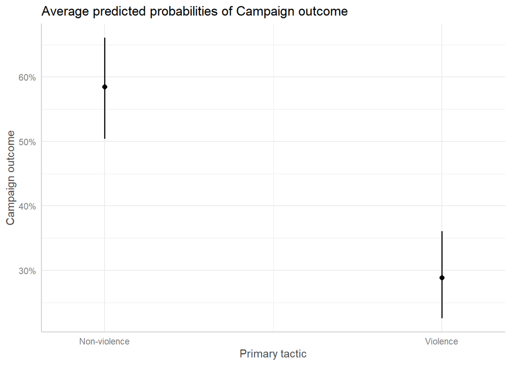

```r
preds<-predict_response(model,
                        terms="tactic",  # predictions for violent vs. non-violent
                        margin='empirical')

plot(preds)
```

Or I can plot at different values of a continuous covariate:

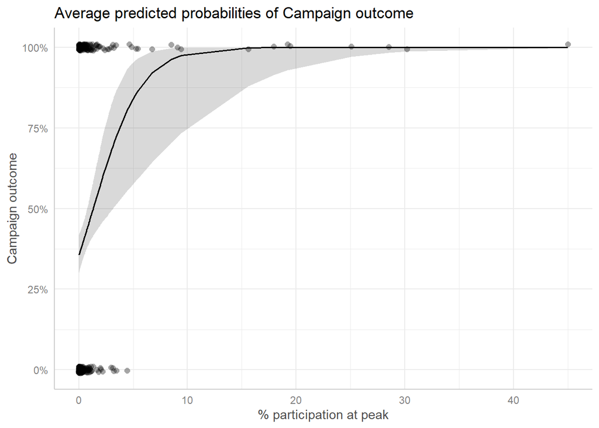

```r
preds<-predict_response(model2,
                        terms="percent_pop[all]",  # prediction at all values of percent_pop
                        margin='empirical')  # with these values at 1 and 1


plot(preds,
     show_data=TRUE, # add points for observed data
     jitter=.01)
```

Or plot the effect across different values of tactic:

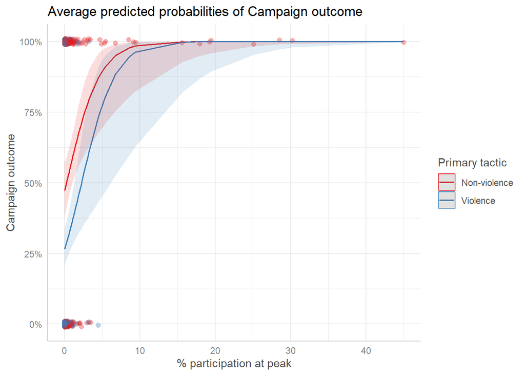

```r
preds<-predict_response(model2,
                        #predictions at different values for these covariates
                        terms=c("percent_pop[all]", "tactic"),
                        margin='empirical')  # with everything else held at observed values


plot(preds,
     show_data=TRUE,
     jitter=.01)
```

## Using MarginalEffects

The [marginal effects package](https://marginaleffects.com/) can perform this process for us and also give us an easy way to get standard errors around the effect sizes. The `avg_comparisons` command calculates the average marginal effect by default:

```r
mfx<-avg_comparisons(model2)

mfx
```

```
          Term                Contrast Estimate Std. Error      z Pr(>|z|)    S
 percent_pop   +1                        0.0986     0.0319  3.092  0.00199  9.0
 state_support yes - no                  0.0375     0.0617  0.609  0.54272  0.9
 tactic        Violence - Non-violence  -0.2028     0.0577 -3.518  < 0.001 11.2
   2.5 %  97.5 %
  0.0361  0.1611
 -0.0833  0.1584
 -0.3158 -0.0898

Type: response
```

```r
# getting the variable labels
labs<-map(navco, .f=~attr(.x, 'label'))|>
  unlist()

mfx|>
  modelsummary(coef_map =labs)
```

|  | (1) |
| --- | --- |
| Primary tactic | -0.203 |
|  | (0.058) |
| % participation at peak | 0.099 |
|  | (0.032) |
| Recieved Military or economic aid | 0.038 |
|  | (0.062) |
| Num.Obs. | 352 |
| AIC | 437.7 |
| BIC | 453.1 |
| Log.Lik. | -214.844 |
| F | 9.433 |
| RMSE | 0.46 |

If no variable is specified in the `variables` argument, it will calculate an marginal effect in the same fashion as above, and will adjust the comparison cases for different variable types automatically.

```r
map<-list('percent_pop' ='marginal effect of one unit increase in % support',
     'state_support' = 'marginal effect of state support (vs none)',
     'tactic' = 'marginal effect of violent tactics (vs non-violent)'
     )

avg_comparisons(model2)|>
  modelsummary(title='Average Marginal Efect',
               coef_map = map,
               statistic = c("conf.int"),
                conf_level = .95,
                note = "95% CI in brackets",
                gof_omit = 'F|RMSE|R2$|AIC|Log.Lik.',
                output ='kableExtra'


             )
```

Average Marginal Efect

|  | (1) |
| --- | --- |
| marginal effect of one unit increase in % support | 0.099 |
|  | [0.036, 0.161] |
| marginal effect of state support (vs none) | 0.038 |
|  | [−0.083, 0.158] |
| marginal effect of violent tactics (vs non-violent) | −0.203 |
|  | [−0.316, −0.090] |
| Num.Obs. | 352 |
| BIC | 453.1 |

95% CI in brackets

This is especially helpful for models that use one or more factor variables, since I can use it to automatically get contrasts at different levels a factor:

```r
complex_model <- glm(outcome~tactic + goal_type, data = navco, family = "binomial")

avg_comparisons(complex_model)
```

```
      Term                   Contrast Estimate Std. Error      z Pr(>|z|)    S
 goal_type Regime Change - Other        0.0812     0.1665  0.488    0.626  0.7
 goal_type Secession - Other           -0.2302     0.1729 -1.332    0.183  2.5
 goal_type Self determination - Other   0.2104     0.1775  1.185    0.236  2.1
 tactic    Violence - Non-violence     -0.2455     0.0514 -4.773   <0.001 19.1
  2.5 % 97.5 %
 -0.245  0.408
 -0.569  0.109
 -0.138  0.558
 -0.346 -0.145

Type: response
```

And then plot them:

[figure not shown]

```r
predict_response(complex_model, term=c('goal_type',
                                       'tactic'
                                       ),margin='empirical')|>
  plot()
```

### Getting standard errors

The default delta-method standard errors should be fine for most use cases. However, if you want simulation or bootstrapped SEs, these can be retrieved using the `inferences` command:

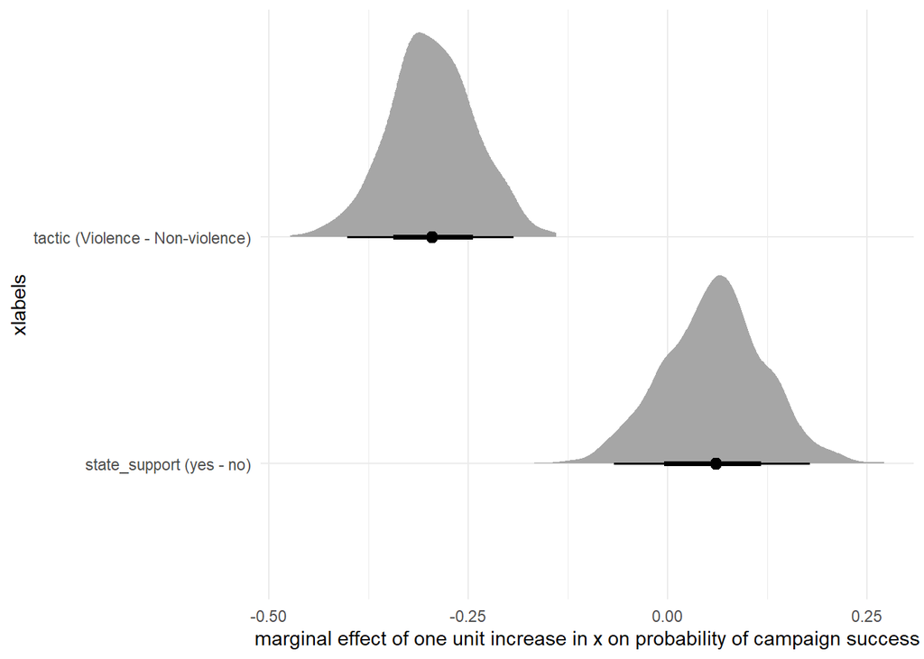

```r
simulated<-avg_comparisons(model)|>
  inferences(method='boot')



simulated$xlabels<-sprintf("%s (%s)", simulated$term, simulated$contrast)



posterior_draws(simulated)|>
  ggplot(aes(x=draw, y=xlabels)) +
  stat_halfeye() +
  theme_minimal() +
  xlab("marginal effect of one unit increase in x on probability of campaign success")
```

### Getting clustered standard errors

Finally, we might want to adjust the standard errors here to account for clustering within countries. We can get cluster robust standard errors by supplying a formula to the `vcov` argument of `avg_comparisons`:

```r
avg_comparisons(model, vcov=~LOCATION)
```

```
          Term                Contrast Estimate Std. Error      z Pr(>|z|)    S
 state_support yes - no                  0.0595     0.0668  0.892    0.373  1.4
 tactic        Violence - Non-violence  -0.2955     0.0589 -5.018   <0.001 20.9
   2.5 % 97.5 %
 -0.0713   0.19
 -0.4108  -0.18

Type: response
```

# Testing the violent flank effects hypothesis

“Violent flank effects” refer to the hypothesis that more moderate social campaigns are more likely to be successful when they have a radical faction that makes them appear more respectable and mainstream. If this is the case, then you would expect to see peaceful campaigns be more successful when they have a violent campaign that operates along side them.(you can read more about this from Erica Chenowith [here](https://www.annualreviews.org/doi/full/10.1146/annurev-polisci-051421-124128))

Since this has been recoded as a factor, including it in a regression model will give us k-1 coefficients. As is the case with linear models, the intercept represents the expected value of the excluded factor level, while the remaining coefficients can be interpreted as the difference between the coefficient category and the baseline category.

```r
flank_model<-glm(outcome ~ tactic_type,family='binomial' , data=navco)
summary(flank_model)
```

```
Call:
glm(formula = outcome ~ tactic_type, family = "binomial", data = navco)

Coefficients:
                                   Estimate Std. Error z value Pr(>|z|)
(Intercept)                          0.4818     0.2775   1.736   0.0826 .
tactic_typeNon-violence (no flank)  -0.2587     0.3384  -0.764   0.4446
tactic_typeViolence                 -1.3393     0.3201  -4.184 2.86e-05 ***
---
Signif. codes:  0 '***' 0.001 '**' 0.01 '*' 0.05 '.' 0.1 ' ' 1

(Dispersion parameter for binomial family taken to be 1)

    Null deviance: 479.15  on 350  degrees of freedom
Residual deviance: 450.53  on 348  degrees of freedom
  (1 observation deleted due to missingness)
AIC: 456.53

Number of Fisher Scoring iterations: 4
```

## Question 1

Get the average marginal effects and predicted probabilities of success for violence vs. non-violence and violent flanks vs. non-violence.

```r
# Code
```

# Model Comparisons

How do we determine whether one model is better than another?

We don’t really have a “residual” term here, so model comparisons based on things like $R^2$ value doesn’t really make sense. Instead, we’ll generally compare these models based on their negative log likelihoods.

## Likelihood Ratio Test

We can use a likelihood ratio test for **nested**[^1] GLM models. If $\mathcal{L_{0}}$ is the log likelihood for a model without some covariate, and $\mathcal{L_{1}}$ is the log likelihood for our model with that covariate included, then we can calculate a likelihood ratio like this:

$$\text{LRT} = -2 \bigg(\ln(\mathcal{L_{0}}) - \ln (\mathcal{L_{1}})\bigg)$$
If the more complex model improves the fit, then this should be a positive number, and if it doesn’t, then this should be a negative number. A likelihood ratio test assumes that these ratios will follow a $\chi^2$ distribution with one degree of freedom, and calculates a p-value that represents the probability of seeing a ratio this large if the null model is “true”.

So if I want to know whether adding `perc_pop` improves the fit, I can compare them using a likelihood ratio test.

```r
model_1 <- glm(outcome ~ tactic , data = navco, family = "binomial")
model_2 <- glm(outcome ~ tactic + percent_pop, data = navco, family = "binomial")
```

Then I would calculate my likelihood ratio:

```r
test_statistic <- -2 * (  logLik(model_1) - logLik(model_2) )
test_statistic
```

```
'log Lik.' 22.77215 (df=2)
```

And then calculate a p.value for this statistic:

```r
pchisq(test_statistic, df = 1, lower.tail = FALSE)
```

```
'log Lik.' 1.823899e-06 (df=2)
```

Based on this p-value, we can reject the null hypothesis that including `perc_pop` does not meaningfully improve our model’s fit.

We can do all of this in one step by using the `anova` function and including the optional `test="LR"` command:

```r
anova(model_1, model_2, test="LR")
```

|  | Resid. Df | Resid. Dev | Df | Deviance | Pr(>Chi) |
| --- | --- | --- | --- | --- | --- |
| 1 | 350 | 452.8305 | NA | NA | NA |
| 2 | 349 | 430.0584 | 1 | 22.77215 | 1.823899e-06 |

## BIC/AIC

Alternatively, we can compare our models based on the Bayesian (BIC) or Akaike (AIC) Information Criteria. Both of these metrics are based on the log likelihood, but they include a penalty for the number of predictors included in the model[^2]. If $k$ is the number of parameters, $n$ is the sample size, and $\mathcal{\hat{L}}$ is the maximum log likelihood, the formula for the BIC and AIC are:

$$\text{BIC} = -2\ln(\mathcal{\hat{L}}) + (k + 1) \ln(n)$$

This built-in penalty means that we can use them to make valid comparisons between two models even if the models aren’t nested.

```r
AIC(model_1) - AIC(model_2)
```

```
[1] 20.77215
```

We can also use the BIC to approximate Bayes Factors for these models. Recall that a Bayes Factor represents the “evidence” in favor of one model over another, so values over 1 suggest `model 2` is better, whereas values less than 1 suggest the simpler model 1 is preferable:

```r
exp( (BIC(model_1) - BIC(model_2) )/2)
```

```
[1] 4695.025
```

A rule of thumb suggests that (logged) Bayes Factors over 5 are strong evidence in favor of the more complicated model, so once again we have strong evidence in favor of the second model:

```r
log(exp( (BIC(model_1) - BIC(model_2) )/2))
```

```
[1] 8.454259
```

## Cross validation accuracy

Finally, we can adopt a machine learning approach and evaluate models based on their ability to correctly classify “unseen” data.

Using the `caret` package, we can perform leave on these data and then compare the models on their ability to correctly classify the held out data. We can even compare completely different types of models. Here’s an example that compares the predictive accuracy of a logit model to a K-Nearest Neighbors (KNN) classifier:

```r
library(caret)


#  leave one out cross-validation
train.control <- trainControl(method = "LOOCV")


cv_logit <- train(outcome ~ tactic + percent_pop, data=navco,
              method = "glm",
              family ='binomial',
              trControl = train.control)


cv_knn <- train(outcome ~ tactic + percent_pop, data=navco,
              method ='knn',
              preProcess = c("center","scale"),
              tuneLength = 20,
              trControl = train.control)
```

Now we can view our results. The k-NN classifier has an additional tuning parameter called $k$, so we test several values for this parameter and then select the one with the highest accuracy:

```r
bind_rows(
  'logit'= cv_logit$results,
  'knn' = cv_knn$results,

  .id ='model'
)|>
  group_by(model)|>
  slice_max(Accuracy, n =1)|>
  select(model, Accuracy, Kappa)
```

| model | Accuracy | Kappa |
| --- | --- | --- |
| knn | 0.6647727 | 0.2707865 |
| logit | 0.6505682 | 0.2488028 |

## Question 2

`percent_pop` has a heavily skewed distribution, which might be unduly influencing our results. Taking the natural log is a common way to address skewness, but since some values of `percent_pop` are zero, we need to add a small positive number to each observation in order to make a log transformation possible:

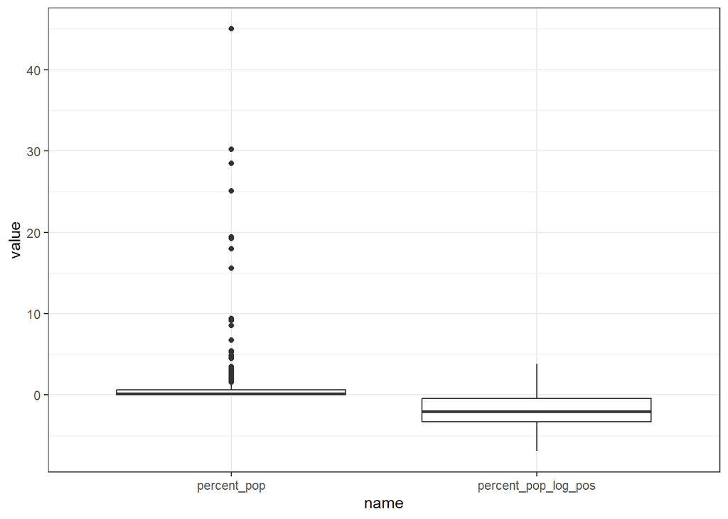

```r
navco$percent_pop_log_pos <- log(navco$percent_pop + .001)

navco|>
  select(starts_with("percent_pop")) |>
  pivot_longer(cols=everything())|>
  ggplot(aes(x=name, y=value)) +
  geom_boxplot() +
  theme_bw()
```

```r
# Code
```

Now we can run a third model using our transformed values for `percent_pop_log_pos`. Does this transformation improve our model fit? What about predictive accuracy?

```r
model_2 <- glm(outcome ~ tactic + percent_pop, data = navco, family = "binomial")
model_3 <- glm(outcome ~ tactic + percent_pop_log_pos, data = navco, family = "binomial")
```

# Bayesian logistic regression model

We’ll try estimating a Bayesian logistic regression model model using `rstanarm` that uses `percent_pop` and `state_support` as predictors:

```r
bayesian_model<-stan_glm(outcome ~ percent_pop + state_support, data=navco,
                       family = binomial(link = "logit"),
                       seed = 999,
                       refresh = 0
                       )
```

### Calculating marginal effects

We can get the marginal effects by taking simulated draws from the posterior distribution from our model. The `posterior_epred` function with a logistic regression will give us simulated predicted probabilities (similar to what you generate when using `predict(model, type='response')`).

`posterior_epred(bayesian_model, draws=10)` would return 10 simulated draws from the posterior distribution for each observations in our data:

```r
pred<-posterior_epred(bayesian_model, draws=10)
dim(pred)
```

```
[1]  10 352
```

We’ll use the `newdata` argument to get predictions under the observed values, and predictions where `percent_pop` increases by 1:

```r
preds0<-posterior_epred(bayesian_model)
preds1<-posterior_epred(bayesian_model,
                        newdata = bayesian_model$model |>
                          mutate(percent_pop = percent_pop  + 1))
```

Then, we can average across the rows of our simulations to get an average marginal effect for `percent_pop` and a 95% credible interval:

```r
# calculate the difference across simulations for each observation
differences<-rowMeans(preds1 - preds0)

# the average effect:
mean(differences)
```

```
[1] 0.1305101
```

```r
# get the 2.5% and 97.5% credible interval
quantile(differences, c(.025, .975))
```

```
     2.5%     97.5%
0.0733669 0.1926319
```

Or we can plot the differences to see a full range of the estimated effects:

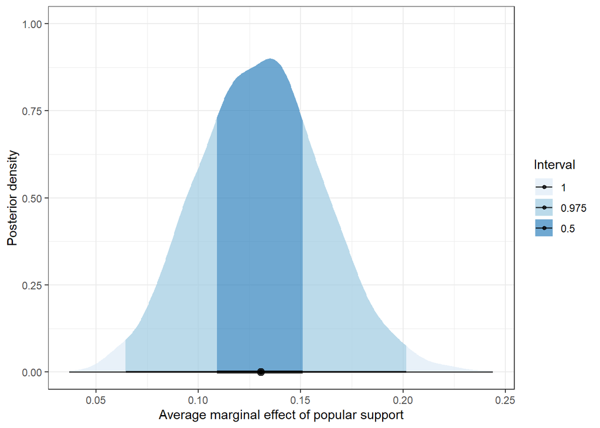

```r
data.frame(differences)|>
  ggplot(aes(x=differences)) +
  stat_halfeye(aes(fill = after_stat(level)), .width = c(0.5, 0.975, 1), alpha = 0.7) +
  theme_bw() +
  labs(x='Average marginal effect of popular support',
       y = 'Posterior density'
       )  +
  scale_fill_brewer('blues', name='Interval')
```

Alternatively, we can use the `avg_comparisons` functions again here to get a marginal effect estimates in one step:

```r
mfx<-avg_comparisons(bayesian_model)
mfx
```

```
          Term Contrast Estimate   2.5 % 97.5 %
 percent_pop   +1         0.1305  0.0734 0.1926
 state_support yes - no  -0.0493 -0.1557 0.0634

Type: response
```

The `get_draws` function will get simulated draws from the posterior distribution. We can use these to get plots showing the average marginal effects for both covariates in the model, along with some additional annotations:

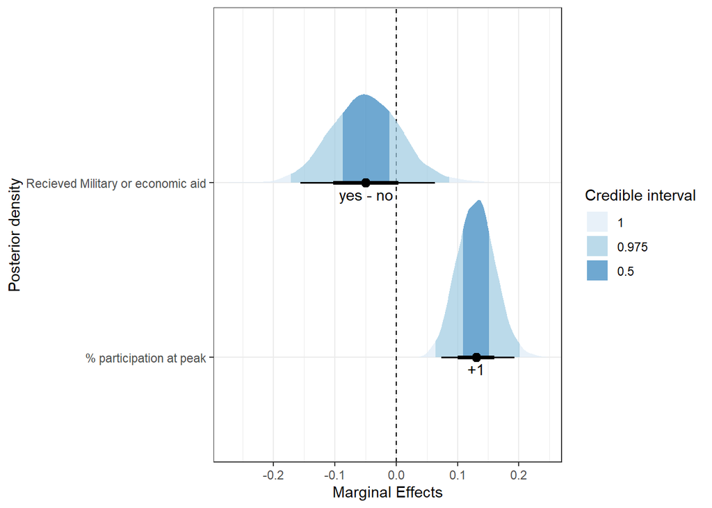

```r
get_draws(mfx) |>
  mutate(term = case_when(term == "percent_pop"  ~ "% participation at peak",
                          term == "state_support"  ~ "Recieved Military or economic aid"
                          )) |>
  ggplot(aes(x = draw, y = term, label = contrast)) +
    geom_vline(xintercept =0, lty=2)+
  stat_slab(aes(fill = after_stat(level)),
            .width = c(0.5, 0.975, 1),
            alpha = 0.7) +
  stat_pointinterval() +
  geom_text(
    stat = "summary",
    fun = "mean",
    vjust = 1.5,
    color = 'black'
  ) +
  labs(x = "Marginal Effects", y = "Posterior density", fill = "variable") +
  theme_bw() +
  scale_fill_brewer('blues', name = 'Credible interval')
```

### Changing the prior

Notice in this case we didn’t explicitly set any prior distribution. `rstanarm` uses [“weakly informative” priors](https://mc-stan.org/rstanarm/articles/priors.html) that are sensible defaults when you don’t have any pre-existing expectations about the model parameters. The defaults for the parameters are:

- Beta coefficients: $\mathcal{N}(0, 2.5 \times \frac{sd(y)}{sd(x)}$
- Intercept term: $\mathcal{N}(\text{mean}(y), 2.5 \times sd(y))$
- Sigma : $\text{Exponential}(\frac{1}{sd(y)})$

```r
prior_summary(bayesian_model)
```

```
Priors for model 'bayesian_model'
------
Intercept (after predictors centered)
 ~ normal(location = 0, scale = 2.5)

Coefficients
  Specified prior:
    ~ normal(location = [0,0], scale = [2.5,2.5])
  Adjusted prior:
    ~ normal(location = [0,0], scale = [0.61,5.70])
------
See help('prior_summary.stanreg') for more details
```

This prior is called “weakly informative” because, when there are lots of parameters or very little data, it will moderately shrink the coefficient estimates toward zero.

We can also plot the prior and posterior distributions for comparison:

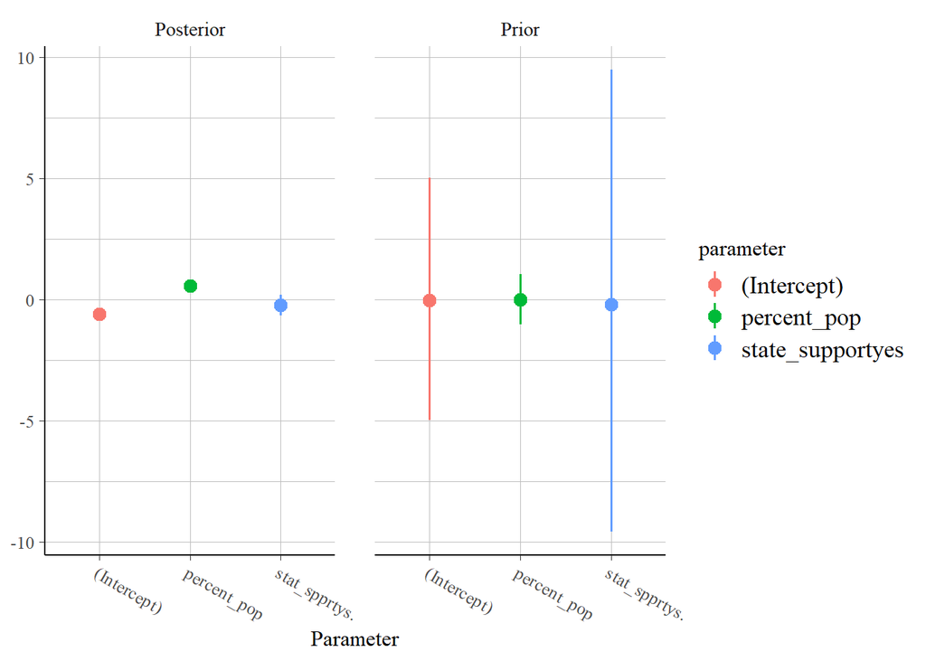

```r
posterior_vs_prior(bayesian_model)
```

The default priors in `rstanarm` often work very well, but we can experiment with adjusting them to see how it impacts our results. Take a look at what changes if we modify the prior on `percent_pop` to $\mathcal{N}(0, \frac{sd(y)}{sd(x)})$ instead of $\mathcal{N}(0, 2.5 \times \frac{sd(y)}{sd(x)})$. This implies that we have a somewhat stronger belief that the actual coefficient for this variable is zero.

```r
bayesian_model2<-stan_glm(outcome ~ percent_pop + state_support, data=navco,
                       family = binomial(link = "logit"),
                       seed = 999,
                       refresh = 0 ,
                       prior = normal(location=c(0, 0),
                                      scale=c(1, 2.5),
                                      autoscale=TRUE),
                       )

prior_summary(bayesian_model2)
```

```
Priors for model 'bayesian_model2'
------
Intercept (after predictors centered)
 ~ normal(location = 0, scale = 2.5)

Coefficients
  Specified prior:
    ~ normal(location = [0,0], scale = [1.0,2.5])
  Adjusted prior:
    ~ normal(location = [0,0], scale = [0.24,5.70])
------
See help('prior_summary.stanreg') for more details
```

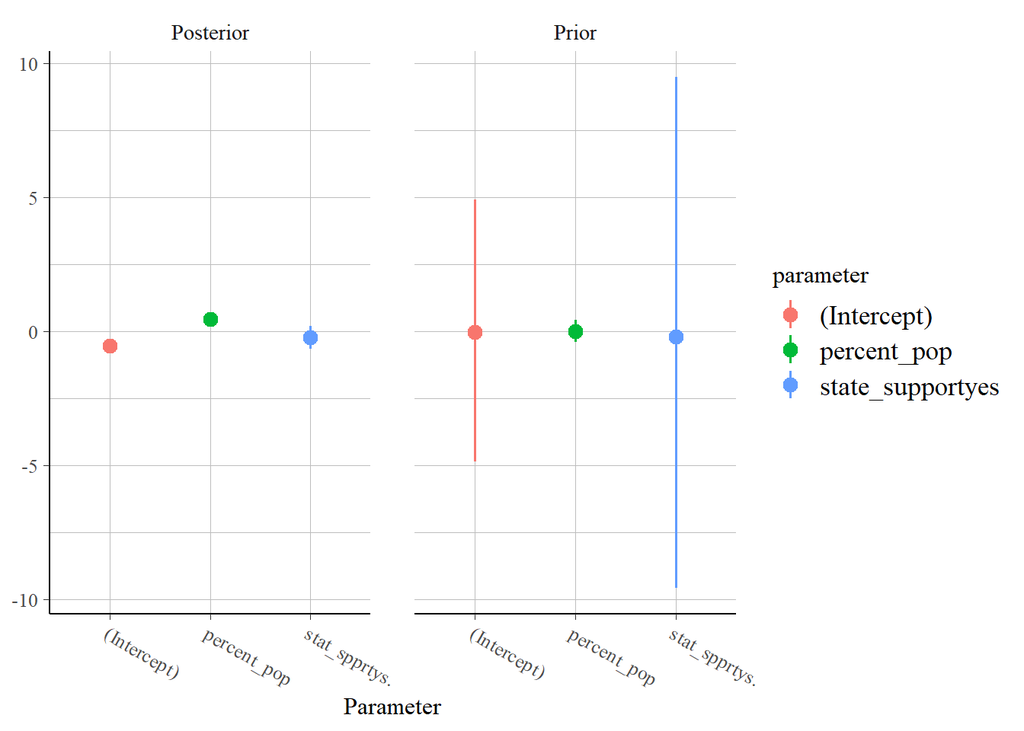

```r
posterior_vs_prior(bayesian_model2)
```

Checking the marginal effects, we see a slightly weaker effect for `percent_pop` under this more informative prior, which makes sense, given that we started with a stronger belief that the effect of this variable was 0:

```r
mfx<-avg_comparisons(bayesian_model2)
mfx
```

```
          Term Contrast Estimate   2.5 % 97.5 %
 percent_pop   +1         0.1031  0.0558 0.1561
 state_support yes - no  -0.0502 -0.1568 0.0597

Type: response
```

Note that the effect of specifying a narrower prior isn’t exactly dramatic here. With a simple model and a relatively large sample, the data is generally going to be more informative than our prior distribution, so we wouldn’t expect to see huge differences at different prior values.

## Footnotes

[^1]: Models are nested if the covariates in the simpler model are a subset of the more complex one. If you could reproduce model A by removing coefficients from model B, then model A is nested in model B.
[^2]: The BIC penalty generally favors more parsimonious models whereas the AIC places more weight on predictive accuracy.